# Práctica 1 - Minería de Datos

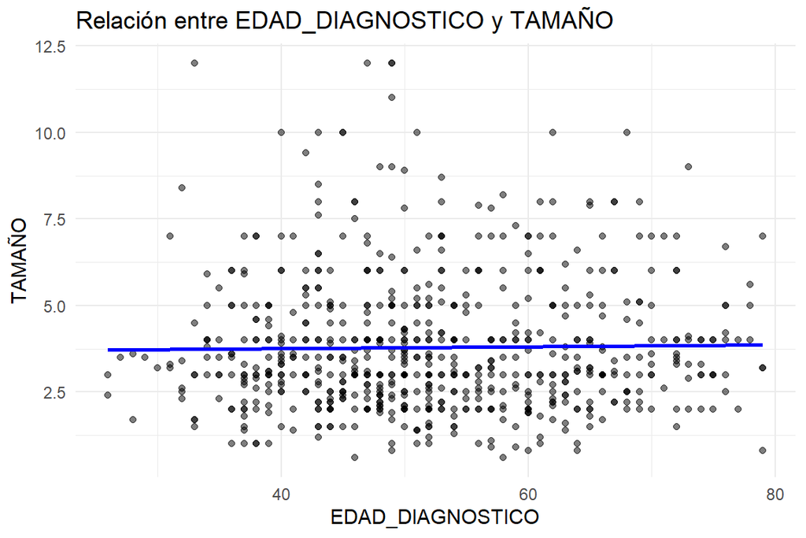

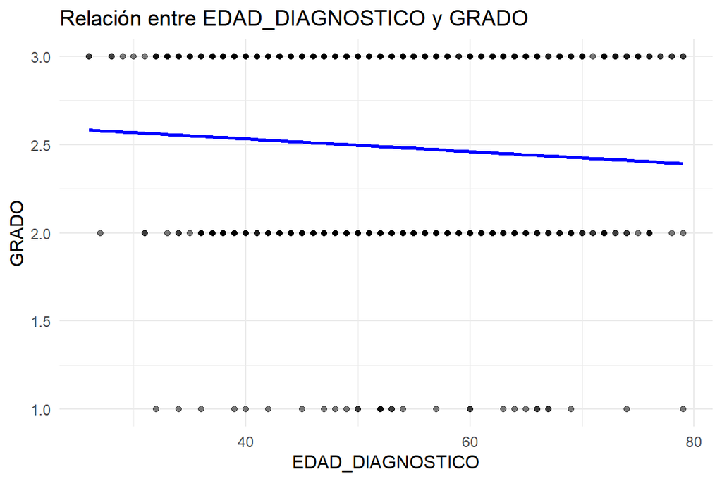

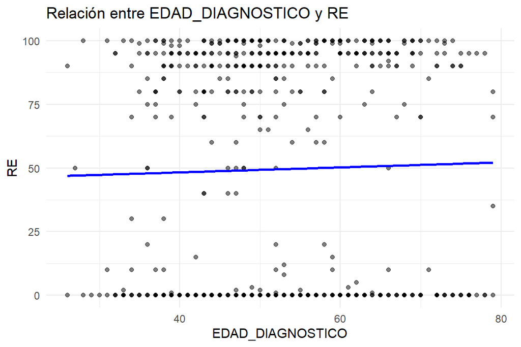

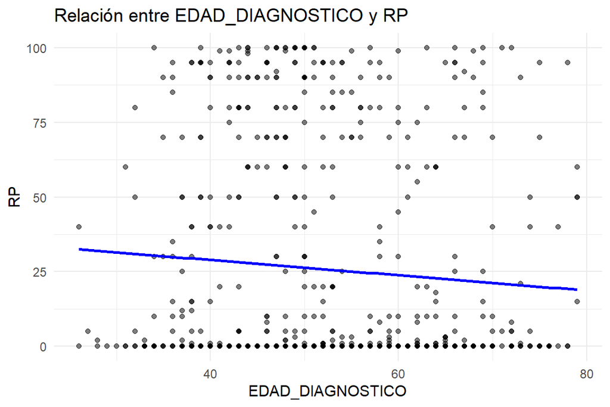

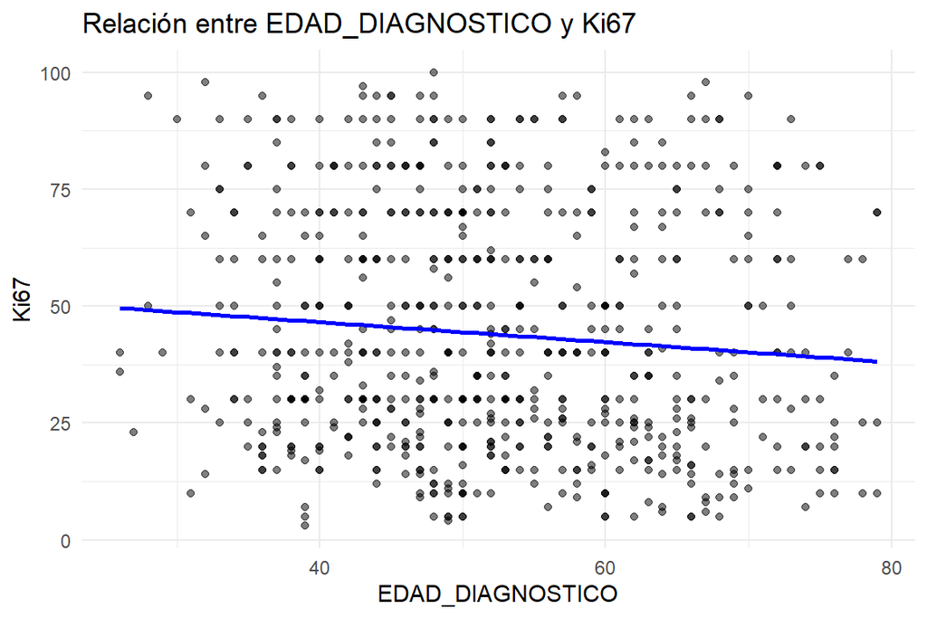

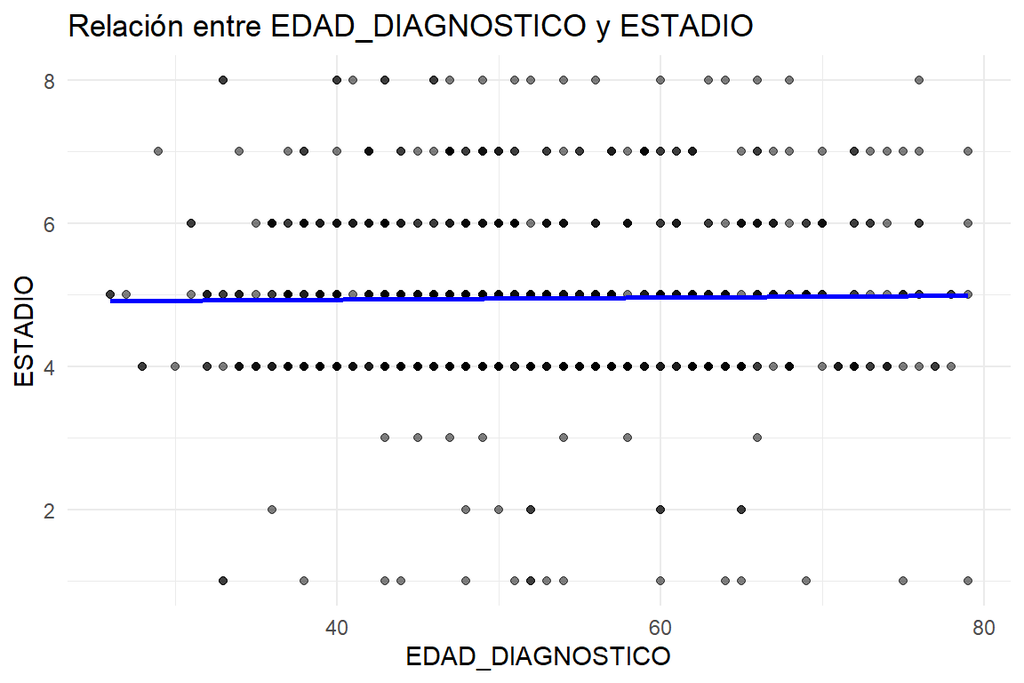

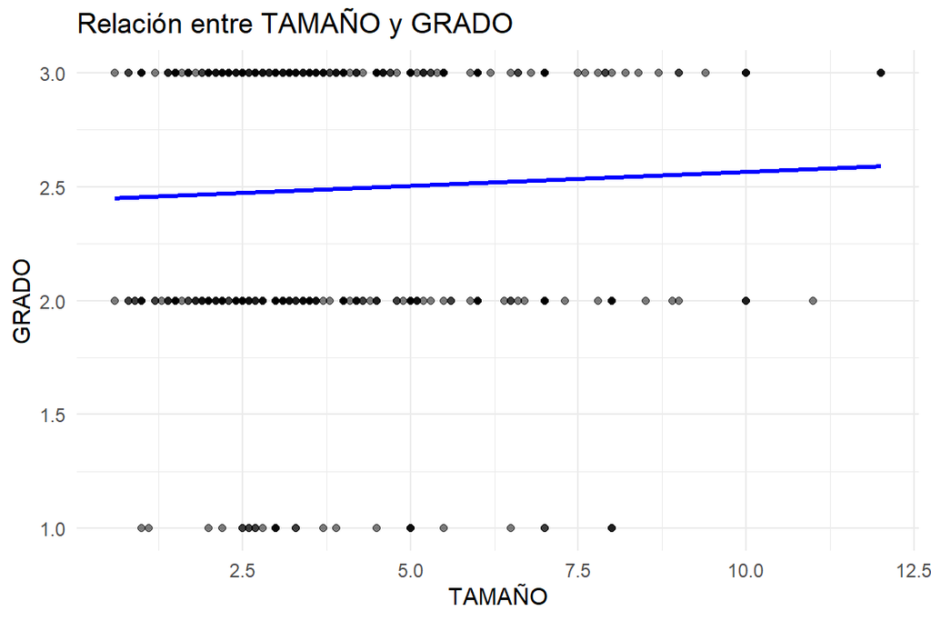

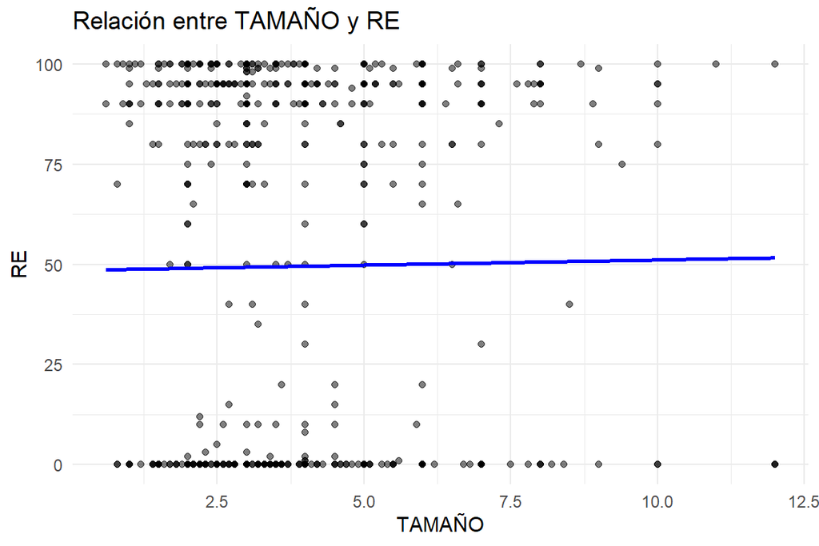

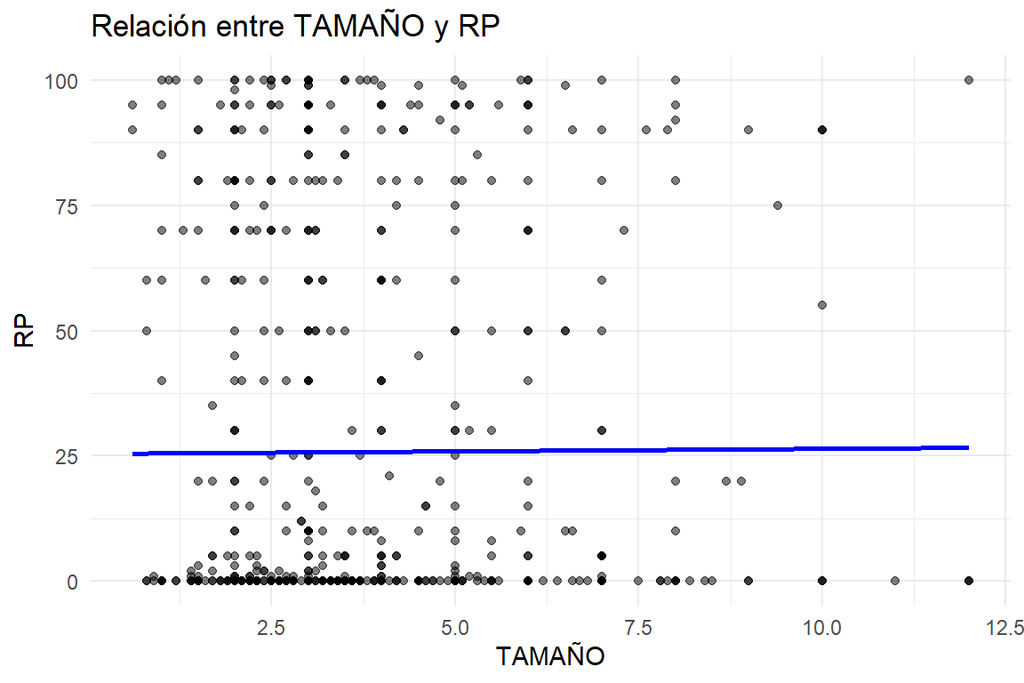

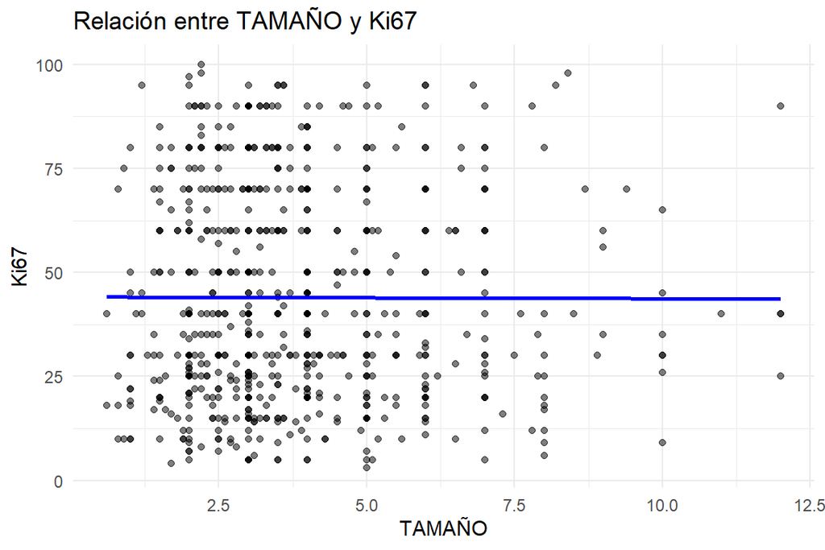

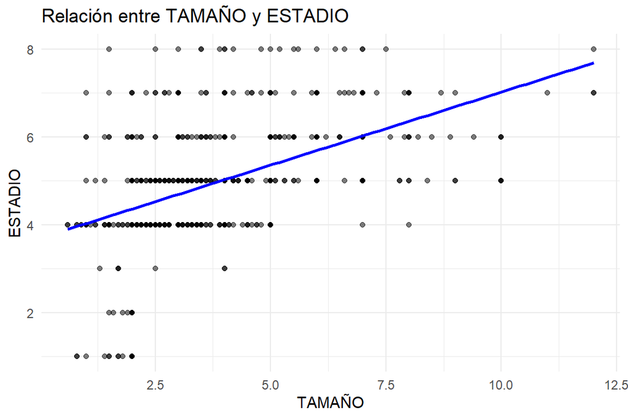

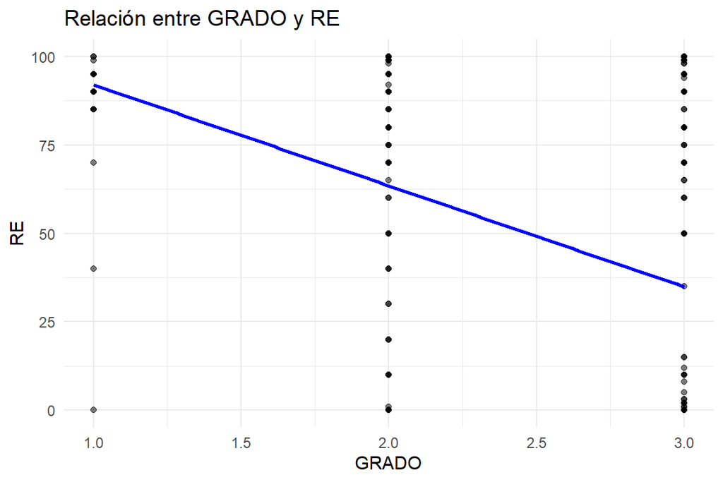

[9 more figures not shown]

```r
# Cargar librerías necesarias
library(ggpubr)
library(dplyr)
library(moments)
library(ggplot2)

# Lista de variables numéricas
vars_num <- c("EDAD_DIAGNOSTICO", "TAMAÑO", "GRADO", "RE", "RP", "Ki67", "ESTADIO")

# Crear dataframe para resultados
resultados_correlacion <- data.frame(
  Variable_1 = character(),
  Variable_2 = character(),
  Metodo = character(),
  Correlacion = numeric(),
  P_valor = numeric(),
  Interpretacion = character(),
  stringsAsFactors = FALSE
)

# Función para evaluar normalidad
es_normal <- function(variable) {
  if (length(variable) > 50) {
    skewness_value <- skewness(variable, na.rm = TRUE)
    kurtosis_value <- kurtosis(variable, na.rm = TRUE)
    return(abs(skewness_value) < 2 & abs(kurtosis_value - 3) < 2)
  } else {
    return(shapiro.test(variable)$p.value > 0.05)
  }
}

# Bucle para análisis de correlación y generación de gráficos
for (i in 1:(length(vars_num)-1)) {
  for (j in (i+1):length(vars_num)) {
    var1 <- datos[[vars_num[i]]]
    var2 <- datos[[vars_num[j]]]

    # Evaluar normalidad
    normal1 <- es_normal(var1)
    normal2 <- es_normal(var2)
    metodo <- ifelse(normal1 & normal2, "pearson", "spearman")

    # Correlación
    cor_test <- cor.test(var1, var2, method = metodo)
    cor_valor <- cor_test$estimate
    p_valor <- cor_test$p.value

    # Interpretación
    interpretacion <- case_when(
      abs(cor_valor) >= 0.9 ~ "Muy fuerte",
      abs(cor_valor) >= 0.7 ~ "Fuerte",
      abs(cor_valor) >= 0.5 ~ "Moderada",
      abs(cor_valor) >= 0.3 ~ "Débil",
      TRUE ~ "Muy débil o nula"
    )

    # Guardar resultado
    resultados_correlacion <- resultados_correlacion %>%
      add_row(
        Variable_1 = vars_num[i],
        Variable_2 = vars_num[j],
        Metodo = metodo,
        Correlacion = round(cor_valor, 3),
        P_valor = round(p_valor, 5),
        Interpretacion = interpretacion
      )

    # Generar gráfico de dispersión con regresión lineal
    p <- ggplot(datos, aes_string(x = vars_num[i], y = vars_num[j])) +
      geom_point(alpha = 0.5) +
      geom_smooth(method = "lm", color = "blue", se = FALSE) +
      labs(
        x = vars_num[i],
        y = vars_num[j],
        title = paste("Relación entre", vars_num[i], "y", vars_num[j])
      ) +
      theme_minimal()

    print(p)
  }
}
```

```r
# Mostrar tabla de resultados
print(resultados_correlacion)
```

```
##          Variable_1 Variable_2   Metodo Correlacion P_valor   Interpretacion
## 1  EDAD_DIAGNOSTICO     TAMAÑO spearman       0.018 0.63081 Muy débil o nula
## 2  EDAD_DIAGNOSTICO      GRADO  pearson      -0.070 0.06603 Muy débil o nula
## 3  EDAD_DIAGNOSTICO         RE  pearson       0.024 0.52162 Muy débil o nula
## 4  EDAD_DIAGNOSTICO         RP  pearson      -0.079 0.03780 Muy débil o nula
## 5  EDAD_DIAGNOSTICO       Ki67  pearson      -0.096 0.01104 Muy débil o nula
## 6  EDAD_DIAGNOSTICO    ESTADIO  pearson       0.012 0.74405 Muy débil o nula
## 7            TAMAÑO      GRADO spearman       0.060 0.11278 Muy débil o nula
## 8            TAMAÑO         RE spearman      -0.032 0.39165 Muy débil o nula
## 9            TAMAÑO         RP spearman      -0.025 0.51142 Muy débil o nula
## 10           TAMAÑO       Ki67 spearman       0.007 0.85378 Muy débil o nula
## 11           TAMAÑO    ESTADIO spearman       0.507 0.00000         Moderada
## 12            GRADO         RE  pearson      -0.366 0.00000            Débil
## 13            GRADO         RP  pearson      -0.289 0.00000 Muy débil o nula
## 14            GRADO       Ki67  pearson       0.445 0.00000            Débil
## 15            GRADO    ESTADIO  pearson       0.008 0.83771 Muy débil o nula
## 16               RE         RP  pearson       0.630 0.00000         Moderada
## 17               RE       Ki67  pearson      -0.422 0.00000            Débil
## 18               RE    ESTADIO  pearson       0.120 0.00143 Muy débil o nula
## 19               RP       Ki67  pearson      -0.334 0.00000            Débil
## 20               RP    ESTADIO  pearson       0.027 0.47103 Muy débil o nula
## 21             Ki67    ESTADIO  pearson      -0.053 0.16503 Muy débil o nula
```

Los resultados del análisis bivariante muestran correlaciones que, en general, son coherentes con el conocimiento clínico actual sobre el cáncer de mama. La mayoría de las asociaciones observadas son muy débiles o nulas, lo que sugiere que muchas de estas variables no están directamente relacionadas de forma lineal, o bien que su efecto podría estar mediado por otros factores clínicos o moleculares.

Entre las relaciones más relevantes, destaca una correlación moderada entre TAMAÑO y ESTADIO (r = 0.507, p < 0.001), lo cual es esperable, ya que el tamaño del tumor es un componente directo del sistema de estadificación TNM. Asimismo, se observa una relación moderada entre RE y RP (r = 0.630), consistente con la coexpresión habitual de receptores hormonales en los tumores luminales.

-GRADO y Ki67 (r = 0.445): lo que indica que los tumores de mayor grado histológico presentan una mayor tasa de proliferación celular, en línea con su biología más agresiva.

-RE y Ki67 (r = -0.422), y RP y Ki67 (r = -0.334): estas correlaciones negativas respaldan que a mayor proliferación tumoral, menor expresión de receptores hormonales, lo cual es característico de tumores menos diferenciados.

-GRADO y RE (r = -0.366): lo que sugiere que los tumores de alto grado tienden a perder la expresión estrogénica, volviéndose menos hormonodependientes.

Por otro lado, muchas de las correlaciones entre variables clínicas como EDAD_DIAGNOSTICO, TAMAÑO, RE, RP o ESTADIO presentan valores cercanos a cero y no alcanzan significación estadística, indicando ausencia de relación lineal directa. Por ejemplo, la relación entre EDAD_DIAGNOSTICO y TAMAÑO fue prácticamente nula (r = 0.018), y la mayoría de los pares similares presentaron resultados similares.

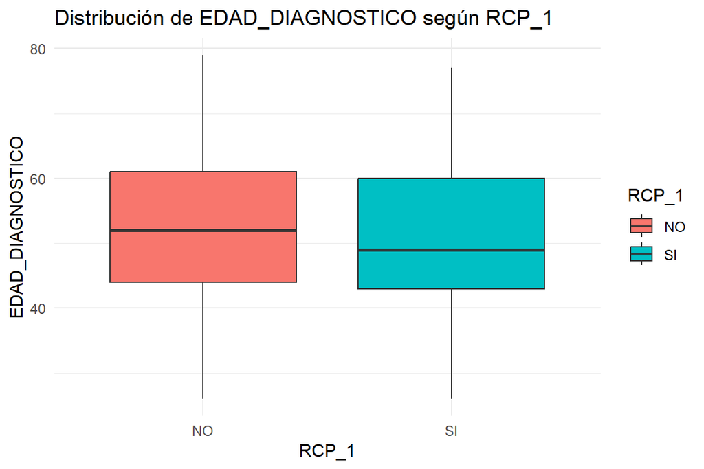

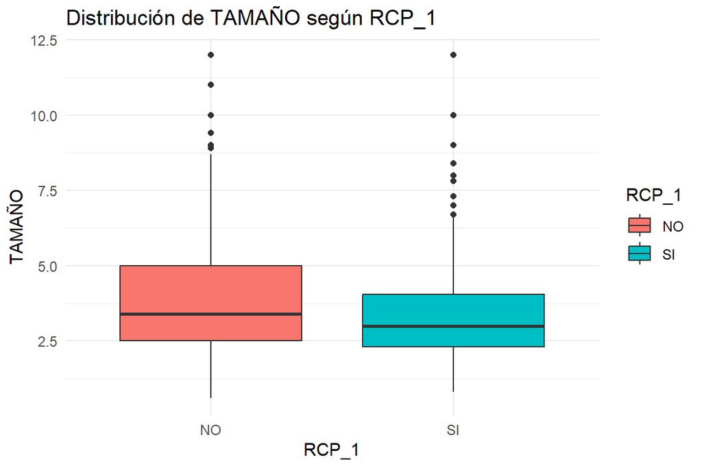

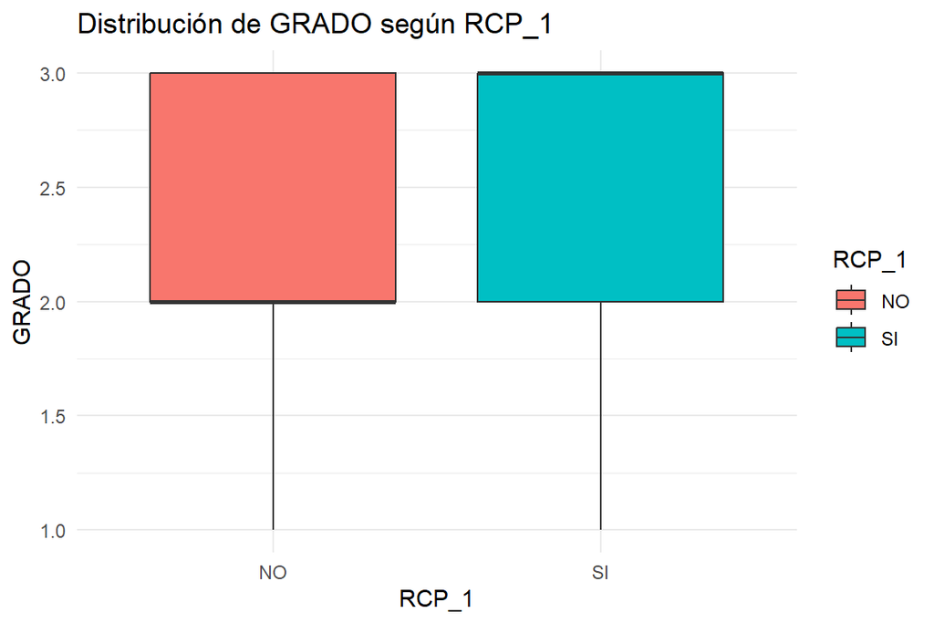

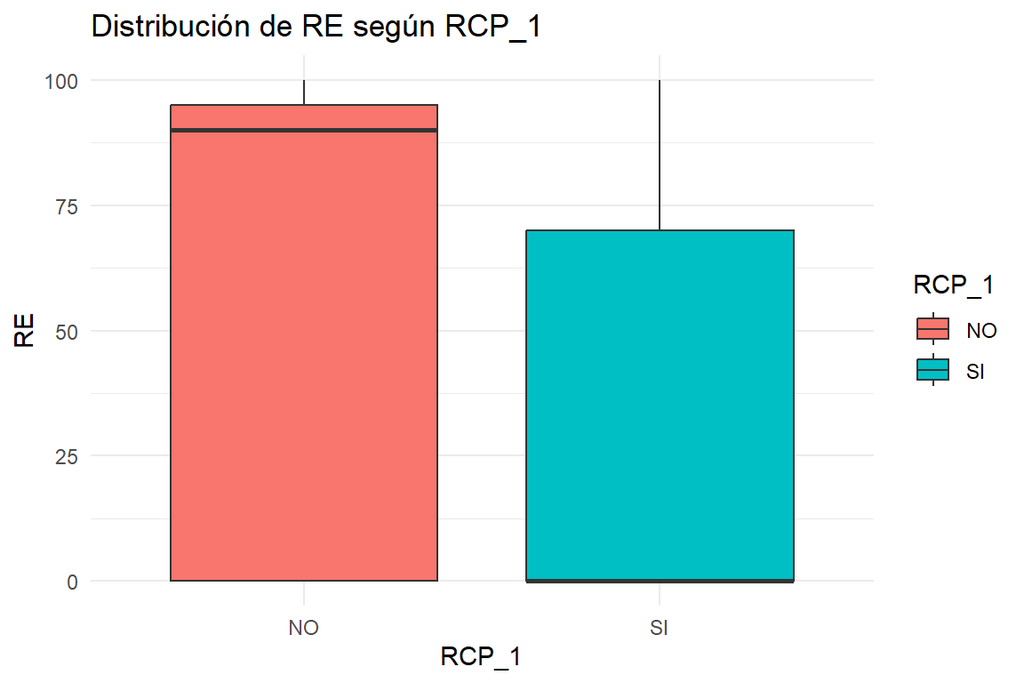

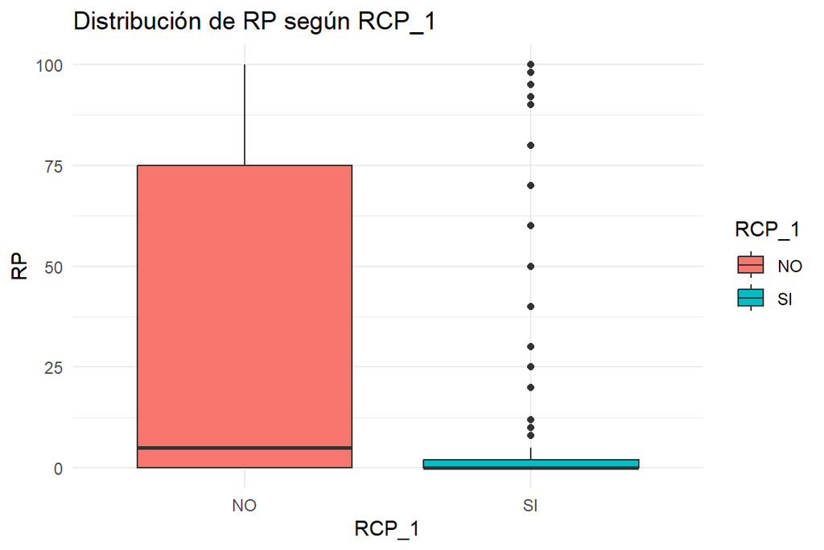

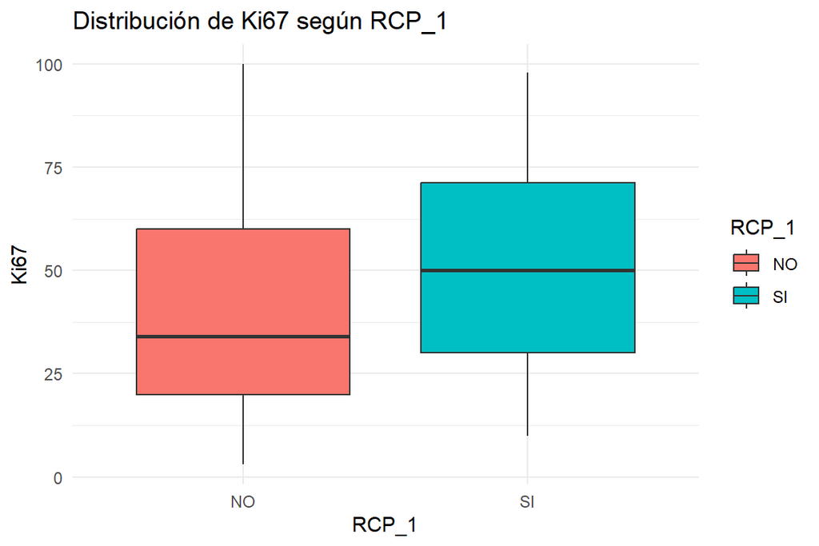

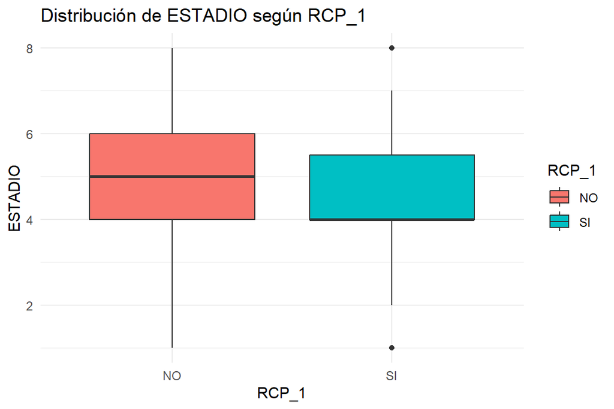

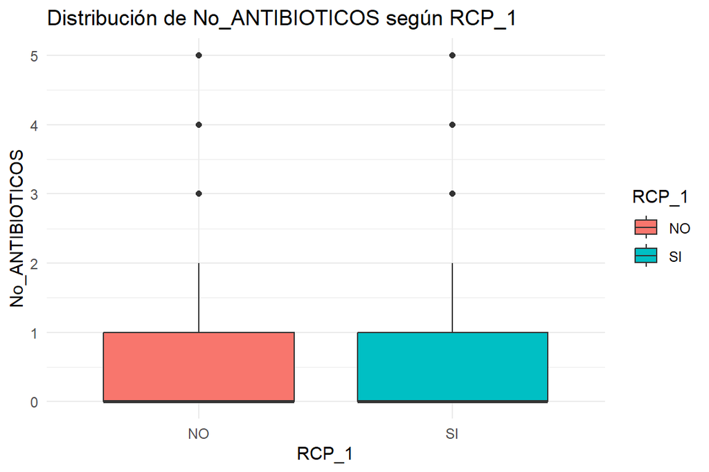

```r
# Cargar librerías necesarias
library(dplyr)
library(ggpubr)
library(moments)
library(ggplot2)

# Obtener clases de columnas
tipos <- sapply(datos, class)

# Forzar TN y NX como factores (categóricas)
datos$Tn <- as.factor(datos$Tn)
datos$Nx <- as.factor(datos$Nx)


# Identificar variables numéricas y categóricas
vars_numericas <- names(tipos)[tipos %in% c("numeric", "integer")]
vars_categoricas <- names(tipos)[tipos %in% c("character", "factor")]

# Crear combinaciones válidas: numérica vs categórica
vars_num_cat <- expand.grid(
  Variable_Numerica = vars_numericas,
  Variable_Categorica = vars_categoricas,
  stringsAsFactors = FALSE
) %>%
  filter(Variable_Numerica != Variable_Categorica)

# Crear un dataframe para guardar resultados
resultados_num_cat <- data.frame(
  Variable_Numerica = character(),
  Variable_Categorica = character(),
  Metodo = character(),
  Estadistico = numeric(),
  P_valor = numeric(),
  Interpretacion = character(),
  stringsAsFactors = FALSE
)

# Función para evaluar normalidad
es_normal <- function(variable) {
  if (!is.numeric(variable)) return(FALSE)
  variable <- na.omit(variable)
  if (length(variable) == 0) return(FALSE)

  if (length(variable) > 50) {
    skewness_value <- skewness(variable)
    kurtosis_value <- kurtosis(variable)
    return(abs(skewness_value) < 2 & abs(kurtosis_value - 3) < 2)
  } else {
    return(shapiro.test(variable)$p.value > 0.05)
  }
}

# Bucle principal
for (i in seq_len(nrow(vars_num_cat))) {
  var_num_name <- vars_num_cat$Variable_Numerica[i]
  var_cat_name <- vars_num_cat$Variable_Categorica[i]

  var_num <- datos[[var_num_name]]
  var_cat <- as.factor(datos[[var_cat_name]])

  # Validación
  if (!is.numeric(var_num) || length(unique(na.omit(var_cat))) < 2) next

  metodo <- ""
  estadistico <- NA
  p_valor <- NA
  interpretacion <- ""

  normal <- es_normal(var_num)

  # Test según número de niveles
  if (length(unique(var_cat)) == 2) {
    try({
      if (normal) {
        test <- t.test(var_num ~ var_cat)
        metodo <- "T-test"
        estadistico <- test$statistic
        p_valor <- test$p.value
      } else {
        test <- wilcox.test(var_num ~ var_cat)
        metodo <- "Wilcoxon"
        estadistico <- test$statistic
        p_valor <- test$p.value
      }
    }, silent = TRUE)

    # 🟢 SOLO generar boxplot si la variable categórica es RCP_1
    if (var_cat_name == "RCP_1") {
      p <- datos %>%
        filter(!is.na(.data[[var_cat_name]]), !is.na(.data[[var_num_name]])) %>%
        ggplot(aes_string(x = var_cat_name, y = var_num_name, fill = var_cat_name)) +
        geom_boxplot() +
        stat_compare_means(method = metodo) +
        labs(
          title = paste("Distribución de", var_num_name, "según", var_cat_name),
          x = var_cat_name,
          y = var_num_name,
          fill = var_cat_name
        ) +
        theme_minimal()

      print(p)
    }

  } else {
    # Más de dos niveles
    try({
      if (normal) {
        modelo <- aov(var_num ~ var_cat)
        resumen <- summary(modelo)[[1]]
        metodo <- "ANOVA"
        estadistico <- resumen[["F value"]][1]
        p_valor <- resumen[["Pr(>F)"]][1]
      } else {
        test <- kruskal.test(var_num ~ var_cat)
        metodo <- "Kruskal-Wallis"
        estadistico <- test$statistic
        p_valor <- test$p.value
      }
    }, silent = TRUE)
  }

  if (!is.na(p_valor)) {
    interpretacion <- case_when(
      p_valor < 0.001 ~ "Diferencia muy significativa",
      p_valor < 0.01  ~ "Diferencia significativa",
      p_valor < 0.05  ~ "Diferencia marginalmente significativa",
      TRUE            ~ "No hay diferencia significativa"
    )

    resultados_num_cat <- resultados_num_cat %>%
      add_row(
        Variable_Numerica = var_num_name,
        Variable_Categorica = var_cat_name,
        Metodo = metodo,
        Estadistico = round(estadistico, 3),
        P_valor = round(p_valor, 5),
        Interpretacion = interpretacion
      )
  }
}
```

```r
# Mostrar tabla de resultados
print(resultados_num_cat)
```

```
##     Variable_Numerica       Variable_Categorica         Metodo Estadistico
## 1    EDAD_DIAGNOSTICO         FECHA_DIAGNOSTICO          ANOVA       1.235
## 2              TAMAÑO         FECHA_DIAGNOSTICO Kruskal-Wallis     606.717
## 3               GRADO         FECHA_DIAGNOSTICO          ANOVA       1.445
## 4                  RE         FECHA_DIAGNOSTICO          ANOVA       1.441
## 5                  RP         FECHA_DIAGNOSTICO          ANOVA       1.290
## 6                Ki67         FECHA_DIAGNOSTICO          ANOVA       1.282
## 7             ESTADIO         FECHA_DIAGNOSTICO          ANOVA       1.263
## 8     No_ANTIBIOTICOS         FECHA_DIAGNOSTICO Kruskal-Wallis     602.614
## 9    EDAD_DIAGNOSTICO           FECHA_INICIO_QT          ANOVA       1.090
## 10             TAMAÑO           FECHA_INICIO_QT Kruskal-Wallis     572.329
## 11              GRADO           FECHA_INICIO_QT          ANOVA       1.130
## 12                 RE           FECHA_INICIO_QT          ANOVA       1.285
## 13                 RP           FECHA_INICIO_QT          ANOVA       1.305
## 14               Ki67           FECHA_INICIO_QT          ANOVA       1.123
```

[output cut: 387 more lines]

Con base en los 200 análisis,muchas asociaciones no resultaron estadísticamente significativas, lo cual es común en contextos clínicos con múltiples factores interrelacionados. Sin embargo, destacan varias asociaciones especialmente en variables relevantes como `GRADO`, `RE`, `RP` y `Ki67` frente a categorías como `FENOTIPO_IHQ`, `RCB`, `GRADO_CAT`, `HT_ADY_OK`, o `KI67_DICOT`, lo que confirma que tumores de mayor agresividad tienden a tener mayor proliferación celular (Ki67) y menor expresión de receptores hormonales (RE y RP).

Por ejemplo, `Ki67` mostró diferencias muy significativas según `GRADO_CAT`, `FENOTIPO_IHQ`, y `RCP_1`, lo que refuerza su valor como marcador pronóstico. `RE` también presentó diferencias claras frente a `HER2_CAT`, `RCB` y `HT_ADY_OK`, reflejando la relación inversa entre receptor hormonal y agresividad tumoral. Además, variables como `TAMAÑO` y `ESTADIO` también mostraron diferencias muy significativas frente a categorías como `Tn`, `Nx`, y `RCP_1`, apoyando su inclusión en modelos predictivos.

En contraste, muchas otras asociaciones como `EDAD_DIAGNOSTICO` con múltiples variables categóricas no resultaron significativas, lo que indica que la edad al diagnóstico no siempre impacta directamente en las características biológicas del tumor. También destaca que `No_ANTIBIOTICOS` rara vez mostró diferencias significativas, salvo en su relación con `ANTIBIOTICO` (como era esperable), lo que sugiere una influencia limitada del número de tandas de antibióticos, al menos de forma univariante.

Finalmente, se sugiere que los pacientes con tumores más pequeños tienen mayor probabilidad de alcanzar una RCP.

En cuanto a los boxplots, apreciamos diferencias notables en varias variables en función de la respuesta completa patológica (`RCP_1`). Se observa, por ejemplo, que los pacientes que lograron una RCP (`SI`) tienden a tener tumores más pequeños en comparación con quienes no lo lograron (`NO`), lo cual es consistente con la literatura clínica. En otro, los niveles de receptores de progesterona (`RP`) son visiblemente más altos en pacientes sin RCP, mientras que en los que sí respondieron completamente, los valores de `RP` son cercanos a cero. Esto sugiere que una baja expresión hormonal podría estar asociada a una mejor respuesta a la quimioterapia, un patrón compatible con fenotipos más agresivos (como los triple negativos) que suelen responder mejor a estos esquemas. Ambas visualizaciones refuerzan hallazgos clínicamente relevantes.

[figure not shown]

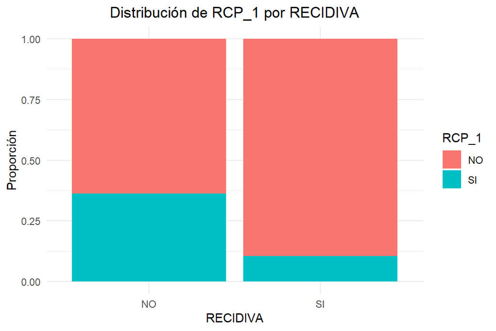

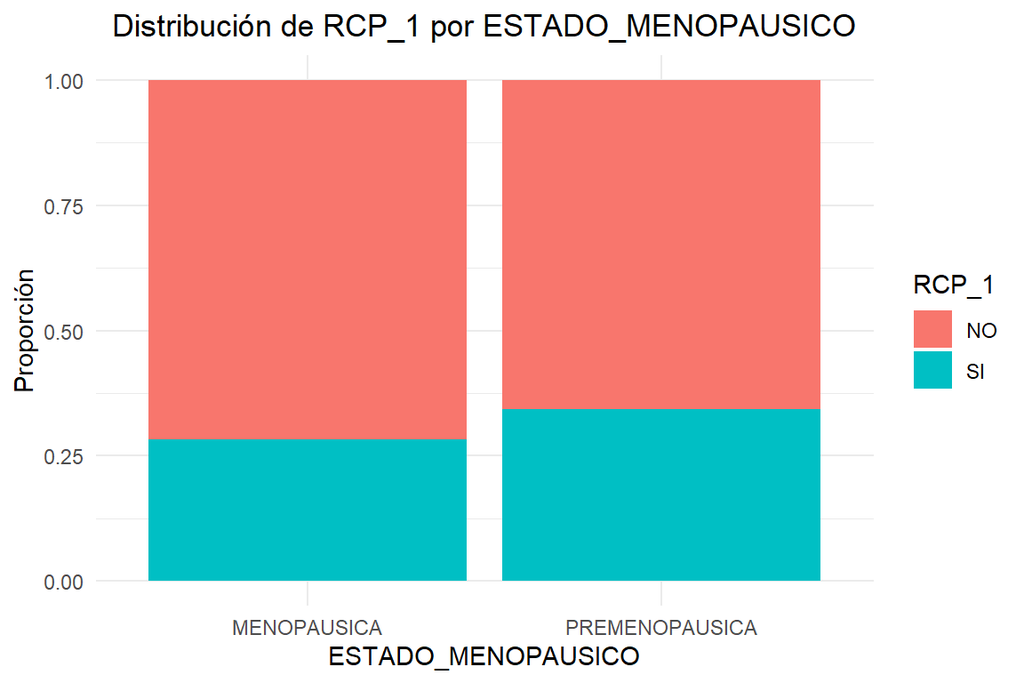

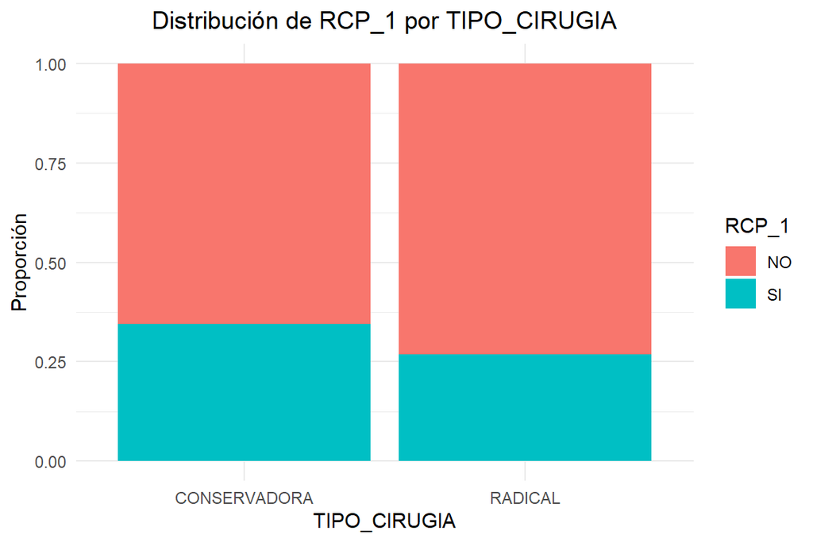

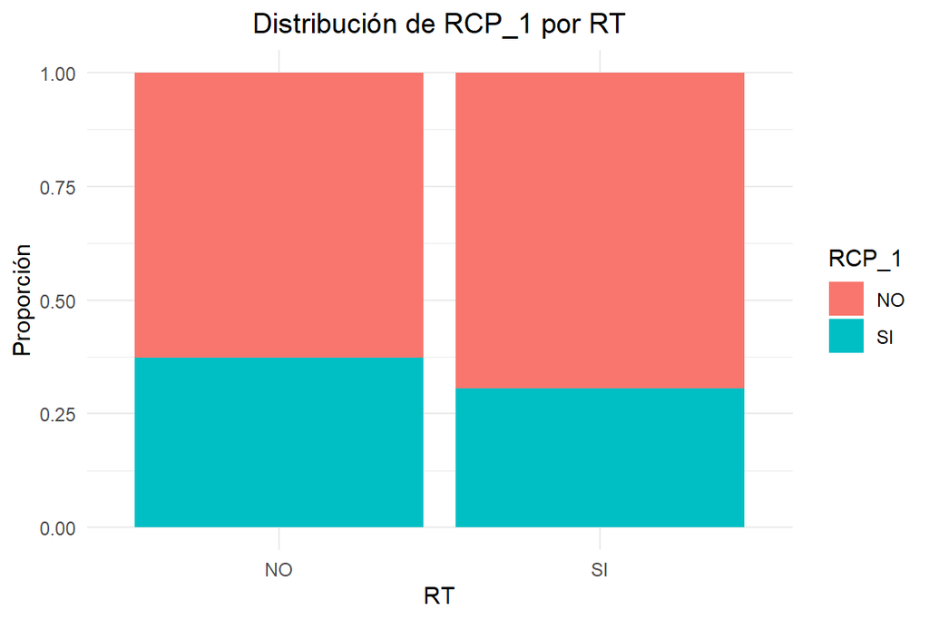

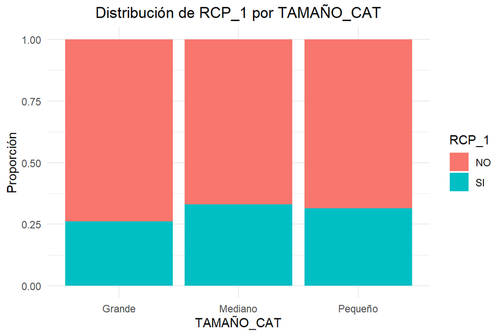

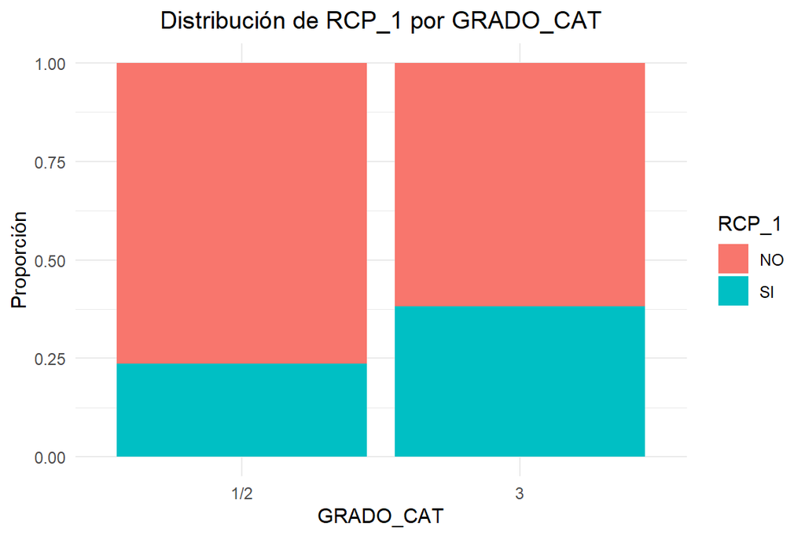

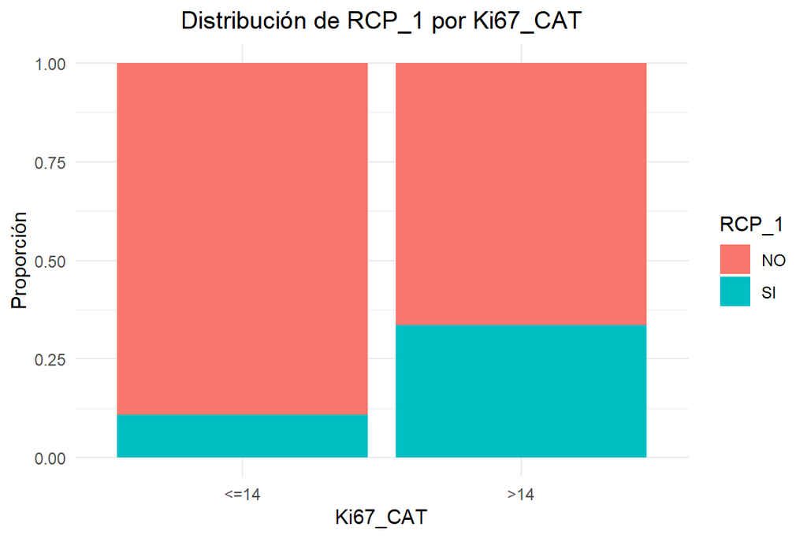

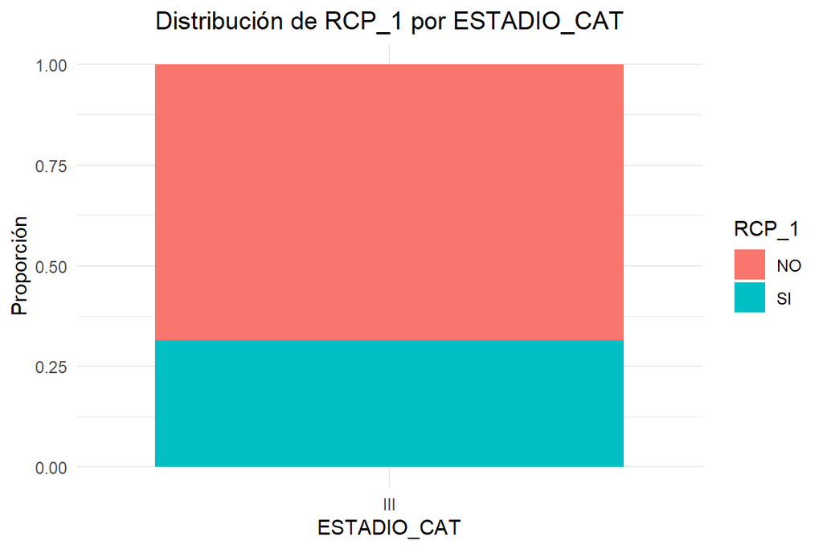

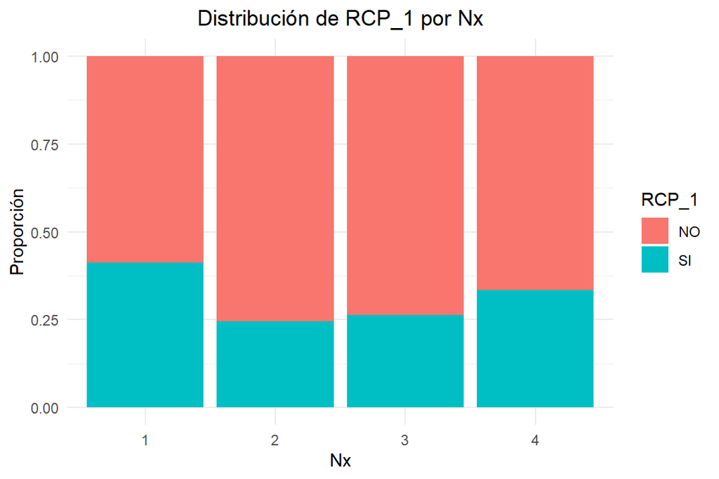

```r
# Cargar librerías necesarias
library(dplyr)
library(ggplot2)
library(rlang)

# 1. Limpiar nombres de columnas de saltos de línea
names(datos) <- gsub("[\\n\\r]", "", names(datos))

# 2. Vector de variables categóricas de interés
vars_cat_names <- c("RCP_1", "HT_ADY_OK", "RECIDIVA", "ESTADO_ULTIMO_CONTROL", "SEXO",
                    "ESTADO_MENOPAUSICO", "TIPO_CIRUGIA", "RT", "TAMAÑO_CAT",
                    "GRADO_CAT", "Ki67_CAT", "ESTADIO_CAT", "Tn", "Nx")

# 3. Generar todas las combinaciones posibles de pares (sin repeticiones)
vars_cat <- combn(vars_cat_names, 2, simplify = FALSE)

# 4. Filtrar combinaciones que realmente existen en el dataset
vars_cat <- vars_cat[sapply(vars_cat, function(pair) all(pair %in% colnames(datos)))]


# 4. Crear dataframe vacío para almacenar resultados
resultados <- data.frame(
  Variable_1 = character(),
  Variable_2 = character(),
  Metodo = character(),
  P_valor = numeric(),
  Interpretacion = character(),
  stringsAsFactors = FALSE
)

# 5. Bucle por cada par de variables
for (pair in vars_cat) {
  var1 <- pair[1]
  var2 <- pair[2]

  # Filtrar filas sin NA en las dos variables
  df_sub <- datos %>% filter(!is.na(.data[[var1]]) & !is.na(.data[[var2]]))

  # Crear tabla de contingencia
  tabla <- table(df_sub[[var1]], df_sub[[var2]])

  # TEST: Chi-cuadrado o Fisher con fallback a simulación
  if (any(chisq.test(tabla)$expected <= 5)) {
    test_result <- tryCatch({
      fisher.test(tabla)
    }, error = function(e) {
      fisher.test(tabla, simulate.p.value = TRUE, B = 5000)
    })
    metodo <- "Fisher"
  } else {
    test_result <- chisq.test(tabla)
    metodo <- "Chi-cuadrado"
  }

  # Añadir resultados al dataframe
  resultados <- rbind(resultados, data.frame(
    Variable_1 = var1,
    Variable_2 = var2,
    Metodo = metodo,
    P_valor = round(test_result$p.value, 5),
    Interpretacion = ifelse(test_result$p.value < 0.05, "✅ Significativa", "❌ No significativa")
  ))

  # 6. Gráfico de barras si una de las variables es RCP_1
  if ("RCP_1" %in% pair) {
    var_x <- ifelse(var1 == "RCP_1", var2, var1)

    grafico <- ggplot(df_sub, aes(x = !!sym(var_x), fill = RCP_1)) +
      geom_bar(position = "fill") +
      labs(
        title = paste("Distribución de RCP_1 por", var_x),
        y = "Proporción", x = var_x, fill = "RCP_1"
      ) +
      theme_minimal() +
      theme(plot.title = element_text(hjust = 0.5))

    print(grafico)
  }
}
```

```r
# 7. Mostrar resultados ordenados por significancia
resultados <- resultados %>% arrange(P_valor)
print(resultados)
```

```
##            Variable_1         Variable_2       Metodo P_valor
## 1               RCP_1           RECIDIVA Chi-cuadrado 0.00000
## 2               RCP_1        ESTADIO_CAT Chi-cuadrado 0.00000
## 3           HT_ADY_OK        ESTADIO_CAT Chi-cuadrado 0.00000
## 4            RECIDIVA        ESTADIO_CAT Chi-cuadrado 0.00000
## 5        TIPO_CIRUGIA                 RT Chi-cuadrado 0.00000
## 6        TIPO_CIRUGIA         TAMAÑO_CAT Chi-cuadrado 0.00000
## 7        TIPO_CIRUGIA        ESTADIO_CAT Chi-cuadrado 0.00000
## 8        TIPO_CIRUGIA                 Nx Chi-cuadrado 0.00000
## 9                  RT        ESTADIO_CAT Chi-cuadrado 0.00000
## 10         TAMAÑO_CAT        ESTADIO_CAT Chi-cuadrado 0.00000
## 11          GRADO_CAT           Ki67_CAT Chi-cuadrado 0.00000
## 12           Ki67_CAT        ESTADIO_CAT Chi-cuadrado 0.00000
## 13        ESTADIO_CAT                 Nx Chi-cuadrado 0.00000
## 14              RCP_1          GRADO_CAT Chi-cuadrado 0.00005
```

[output cut: 97 more lines]

El análisis de asociación entre variables categóricas revela múltiples relaciones clínicamente relevantes. La respuesta completa patológica (RCP_1) muestra una asociación estadísticamente significativa con la hormonoterapia adyuvante (HT_ADY_OK) (p ≈ 0.0002) y una relación altamente significativa con la recidiva tumoral (RECIDIVA) (p < 0.00000002). Estos resultados sugieren que alcanzar una RCP podría estar relacionado con una menor probabilidad de recurrencia y una mayor indicación de hormonoterapia.

Asimismo, HT_ADY_OK también se asocia con RECIDIVA (p ≈ 0.0216), lo cual puede indicar un efecto protector del tratamiento hormonal frente a la recaída. En línea con la práctica clínica, se observa una fuerte relación entre el estado menopáusico y el uso de hormonoterapia (p ≈ 0.0002), reflejando el criterio terapéutico habitual según el perfil hormonal del paciente.

El tipo de cirugía (TIPO_CIRUGIA) también se asocia significativamente con la recidiva (p ≈ 0.0043), posiblemente indicando que ciertos abordajes quirúrgicos podrían estar ligados a un mayor o menor riesgo de recurrencia. Por otra parte, se identifica una asociación significativa entre el grado tumoral (GRADO_CAT) y la recidiva (p ≈ 0.0022), lo que sugiere que tumores de alto grado histológico podrían presentar un comportamiento más agresivo.

Además, el índice proliferativo (Ki67_CAT) se relaciona con el uso de hormonoterapia (p ≈ 0.0002), reforzando su papel como biomarcador en la toma de decisiones terapéuticas. Por el contrario, algunas asociaciones no resultaron significativas, como el sexo (SEXO) con RCP_1 (p = 1) y el tamaño categorizado del tumor (TAMAÑO_CAT) con RCP_1 (p ≈ 0.319), indicando que estas variables no muestran relación directa con la respuesta al tratamiento en este análisis.

# 6 Analisis Multivariante

Por ahora, hemos explorado la relación entre la respuesta completa patológica (RCP) y otras variables del conjunto de datos utilizando análisis bivariantes, tanto de asociación como de correlación. Si bien este tipo de análisis resulta útil como primer acercamiento para identificar posibles vínculos, presenta limitaciones sustanciales cuando se trata de comprender en profundidad qué factores influyen realmente en la probabilidad de alcanzar una RCP.

Una de las principales debilidades del enfoque bivariante es que analiza cada variable por separado, ignorando el contexto en el que interactúan múltiples factores simultáneamente. Esto puede llevar a conclusiones engañosas. Por ejemplo, podríamos observar una aparente relación entre el uso de antibióticos y la RCP, sin tener en cuenta que dicha relación podría estar mediada o explicada por otra variable relevante, como el tipo de quimioterapia administrada. Sin un ajuste por variables concurrentes, este tipo de interpretaciones corre el riesgo de sobreestimar o subestimar efectos reales.

Además, este enfoque no permite identificar interacciones entre variables. Es posible que el impacto de un factor sobre la RCP no sea uniforme, sino que dependa del nivel de otra variable. Por ejemplo, el efecto del fenotipo tumoral sobre la respuesta podría variar según el estado menopáusico de la paciente. Estas interacciones complejas solo pueden detectarse y cuantificarse adecuadamente mediante un análisis multivariante.

También debemos considerar el problema de la colinealidad: cuando dos o más variables están correlacionadas entre sí, el análisis bivariante no puede discernir cuál es la que ejerce realmente el efecto. Esto puede inducir a atribuir erróneamente la influencia de una variable a otra relacionada. El análisis multivariante permite controlar esta colinealidad y distinguir los efectos independientes de cada predictor.

Por último, los análisis bivariantes ofrecen estimaciones “crudas”, es decir, no ajustadas por el resto de variables. En cambio, los modelos multivariantes proporcionan odds ratios ajustados, que representan con mayor fidelidad la influencia real de cada factor sobre la probabilidad de lograr una RCP, controlando por otras covariables.

Por todas estas razones, avanzar hacia un análisis multivariante no solo es un paso lógico, sino necesario. Este enfoque nos permitirá obtener una visión más completa y precisa del fenómeno clínico que estudiamos, identificando los verdaderos determinantes de la respuesta patológica completa, evaluando interacciones relevantes y estimando con mayor exactitud las probabilidades de éxito terapéutico.